# Capstone Project

## Overview

If you are planning on going out to see a movie, how well can you trust online reviews and ratings? *Especially* if the same company showing the rating *also* makes money by selling movie tickets. Do they have a bias towards rating movies higher than they should be rated?

### Goal:

(Based on the 538 article) Determine if Fandango's ratings in 2015 had a bias towards rating movies better to sell more tickets using pandas and visualization skills.

## Part One: Understanding the Background and Data

**The article: [Be Suspicious Of Online Movie Ratings, Especially Fandango’s](http://fivethirtyeight.com/features/fandango-movies-ratings/)**

### The Data

The data behind the story [Be Suspicious Of Online Movie Ratings, Especially Fandango’s](http://fivethirtyeight.com/features/fandango-movies-ratings/) openly available on 538's github: https://github.com/fivethirtyeight/data. There are two csv files, one with Fandango Stars and Displayed Ratings, and the other with aggregate data for movie ratings from other sites, like Metacritic,IMDB, and Rotten Tomatoes.

#### all_sites_scores.csv

`all_sites_scores.csv` contains every film that has a Rotten Tomatoes rating, a RT User rating, a Metacritic score, a Metacritic User score, and IMDb score, and at least 30 fan reviews on Fandango. The data from Fandango was pulled on Aug. 24, 2015.

| Column | Definition |
| --- | --- |
| FILM | The film in question |
| RottenTomatoes | The Rotten Tomatoes Tomatometer score for the film |
| RottenTomatoes_User | The Rotten Tomatoes user score for the film |
| Metacritic | The Metacritic critic score for the film |
| Metacritic_User | The Metacritic user score for the film |
| IMDB | The IMDb user score for the film |
| Metacritic_user_vote_count | The number of user votes the film had on Metacritic |
| IMDB_user_vote_count | The number of user votes the film had on IMDb |

#### fandango_scape.csv

`fandango_scrape.csv` contains every film 538 pulled from Fandango.

| Column | Definiton |
| --- | --- |
| FILM | The movie |
| STARS | Number of stars presented on Fandango.com |
| RATING | The Fandango ratingValue for the film, as pulled from the HTML of each page. This is the actual average score the movie obtained. |
| VOTES | number of people who had reviewed the film at the time we pulled it. |

```python
import pandas as pd
import numpy as np
import matplotlib.pyplot as plt
import seaborn as sns
import scipy

sns.set_style('darkgrid')
```

## Part Two: Exploring Fandango Displayed Scores versus True User Ratings

Let's first explore the Fandango ratings to see if our analysis agrees with the article's conclusion.

```python
fandango = pd.read_csv("fandango_scrape.csv")
fandango.head()
```

|  | FILM | STARS | RATING | VOTES |
| --- | --- | --- | --- | --- |
| 0 | Fifty Shades of Grey (2015) | 4.0 | 3.9 | 34846 |
| 1 | Jurassic World (2015) | 4.5 | 4.5 | 34390 |
| 2 | American Sniper (2015) | 5.0 | 4.8 | 34085 |
| 3 | Furious 7 (2015) | 5.0 | 4.8 | 33538 |
| 4 | Inside Out (2015) | 4.5 | 4.5 | 15749 |

```python
fandango.info()
```

```
<class 'pandas.core.frame.DataFrame'>
RangeIndex: 504 entries, 0 to 503
Data columns (total 4 columns):
 #   Column  Non-Null Count  Dtype
---  ------  --------------  -----
 0   FILM    504 non-null    object
 1   STARS   504 non-null    float64
 2   RATING  504 non-null    float64
 3   VOTES   504 non-null    int64
dtypes: float64(2), int64(1), object(1)
memory usage: 15.9+ KB
```

```python
fandango.describe()
```

|  | STARS | RATING | VOTES |
| --- | --- | --- | --- |
| count | 504.000000 | 504.000000 | 504.000000 |
| mean | 3.558532 | 3.375794 | 1147.863095 |
| std | 1.563133 | 1.491223 | 3830.583136 |
| min | 0.000000 | 0.000000 | 0.000000 |
| 25% | 3.500000 | 3.100000 | 3.000000 |
| 50% | 4.000000 | 3.800000 | 18.500000 |
| 75% | 4.500000 | 4.300000 | 189.750000 |
| max | 5.000000 | 5.000000 | 34846.000000 |

Exploring the relationship between popularity of a film and its rating through a scatterplot.

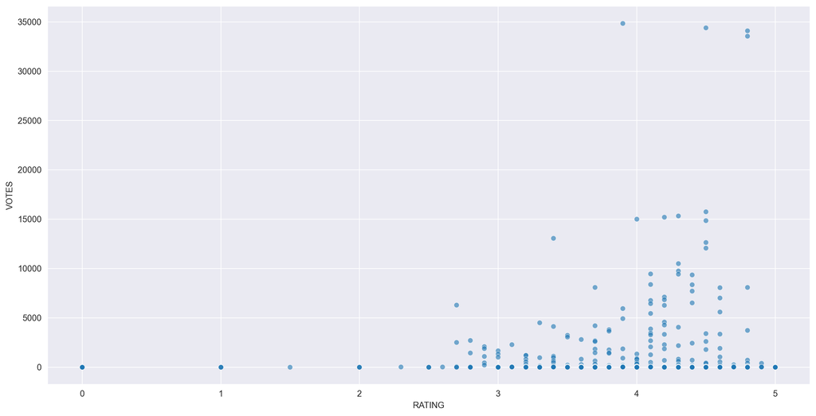

```python
plt.figure(figsize=(16,8), dpi=250)
sns.scatterplot(data=fandango, x = 'RATING', y = 'VOTES', alpha=0.6)
```

Calculate the correlation between the columns

```python
fandango.corr(numeric_only=True)
```

|  | STARS | RATING | VOTES |
| --- | --- | --- | --- |
| STARS | 1.000000 | 0.994696 | 0.164218 |
| RATING | 0.994696 | 1.000000 | 0.163764 |
| VOTES | 0.164218 | 0.163764 | 1.000000 |

Every row in the FILM title column has the same format

```
Film Title Name (Year)
```

Creating a new column that only holds the year as a string

```python
fandango['YEAR'] = fandango['FILM'].apply(lambda s: s.split()[-1].replace('(', '').replace(')', ''))
```

Amount of movies in the Fandango DataFrame per year

```python
fandango['YEAR'].value_counts().sort_values(ascending=False)
```

```
YEAR
2015    478
2014     23
2016      1
1964      1
2012      1
Name: count, dtype: int64
```

Visualizing the count of movies per year with a histogram

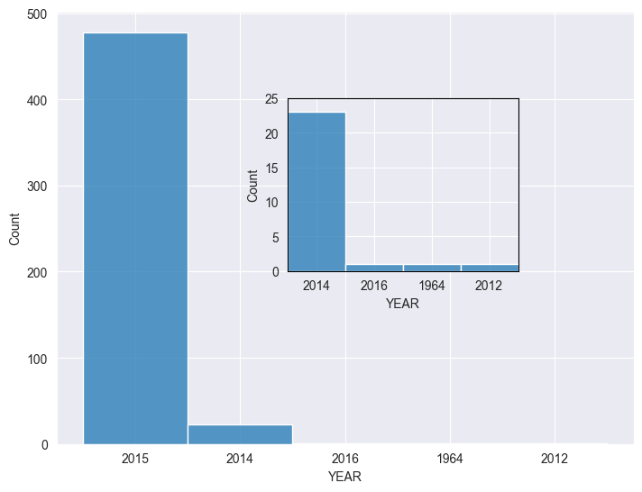

```python
fig = plt.figure(dpi=100)

ax1 = fig.add_axes([0,0,1,1])
sns.histplot(data=fandango, x = 'YEAR', ax = ax1)

ax2 = fig.add_axes([0.4, 0.4, 0.4, 0.4])
sns.histplot(data=fandango, x = 'YEAR')
ax2.set_ylim(0,25)
ax2.set_xlim(0.5,4.5)
ax2.spines[['left', 'right', 'top', 'bottom']].set_color('black')
```

Top 10 movies with the highest number of votes

```python
fandango.nlargest(10, 'VOTES')
```

|  | FILM | STARS | RATING | VOTES | YEAR |
| --- | --- | --- | --- | --- | --- |
| 0 | Fifty Shades of Grey (2015) | 4.0 | 3.9 | 34846 | 2015 |
| 1 | Jurassic World (2015) | 4.5 | 4.5 | 34390 | 2015 |
| 2 | American Sniper (2015) | 5.0 | 4.8 | 34085 | 2015 |
| 3 | Furious 7 (2015) | 5.0 | 4.8 | 33538 | 2015 |
| 4 | Inside Out (2015) | 4.5 | 4.5 | 15749 | 2015 |
| 5 | The Hobbit: The Battle of the Five Armies (2014) | 4.5 | 4.3 | 15337 | 2014 |
| 6 | Kingsman: The Secret Service (2015) | 4.5 | 4.2 | 15205 | 2015 |
| 7 | Minions (2015) | 4.0 | 4.0 | 14998 | 2015 |
| 8 | Avengers: Age of Ultron (2015) | 5.0 | 4.5 | 14846 | 2015 |
| 9 | Into the Woods (2014) | 3.5 | 3.4 | 13055 | 2014 |

How many movies have zero votes?

```python
zerovotes = fandango['VOTES']==0
zerovotes.sum()
```

```
69
```

Creating a new DataFrame of only reviewed films by removing any films that have zero votes

```python
Reviewed_films = fandango[~zerovotes].copy()
Reviewed_films.info()
```

```
<class 'pandas.core.frame.DataFrame'>
Index: 435 entries, 0 to 434
Data columns (total 5 columns):
 #   Column  Non-Null Count  Dtype
---  ------  --------------  -----
 0   FILM    435 non-null    object
 1   STARS   435 non-null    float64
 2   RATING  435 non-null    float64
 3   VOTES   435 non-null    int64
 4   YEAR    435 non-null    object
dtypes: float64(2), int64(1), object(2)
memory usage: 20.4+ KB
```

**As noted in the article, due to HTML and star rating displays, the true user rating may be slightly different than the rating shown to a user. Let's visualize this difference in distributions.**

Multiple kdeplots that display the distribution of ratings that are displayed (STARS) versus what the true rating was from votes (RATING).

```
(0.0, 5.5)
```

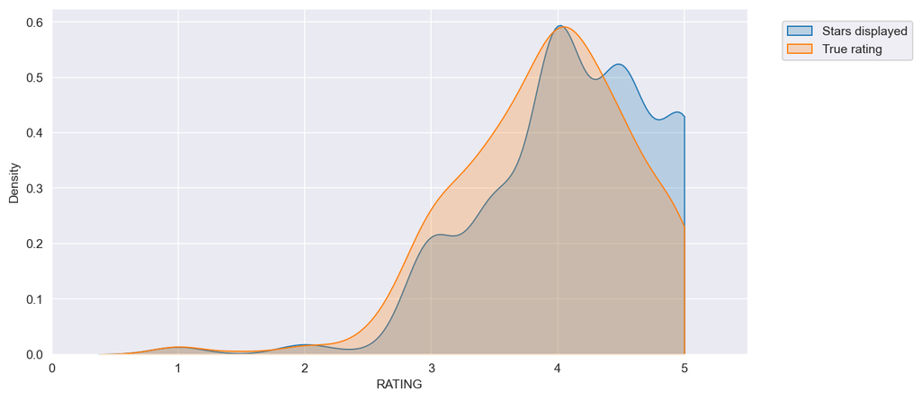

```python
plt.figure(figsize=(10,5), dpi=140)
sns.kdeplot(data=Reviewed_films, x='STARS', fill=True, label='Stars displayed', clip=(0,5))
sns.kdeplot(data=Reviewed_films, x='RATING', fill=True, label='True rating', clip=(0,5))
plt.legend(loc=(1.05,0.85))
plt.xlabel('RATING')
plt.xlim(0,5.5)
```

Quantifying the discrepancy between the STARS displayed and the true RATING.

```python
Reviewed_films['RATING_DIFF'] = Reviewed_films['STARS'] - (Reviewed_films['RATING'])
Reviewed_films['RATING_DIFF'] = Reviewed_films['RATING_DIFF'].round(2)
Reviewed_films
```

|  | FILM | STARS | RATING | VOTES | YEAR | RATING_DIFF |
| --- | --- | --- | --- | --- | --- | --- |
| 0 | Fifty Shades of Grey (2015) | 4.0 | 3.9 | 34846 | 2015 | 0.1 |
| 1 | Jurassic World (2015) | 4.5 | 4.5 | 34390 | 2015 | 0.0 |
| 2 | American Sniper (2015) | 5.0 | 4.8 | 34085 | 2015 | 0.2 |
| 3 | Furious 7 (2015) | 5.0 | 4.8 | 33538 | 2015 | 0.2 |
| 4 | Inside Out (2015) | 4.5 | 4.5 | 15749 | 2015 | 0.0 |
| ... | ... | ... | ... | ... | ... | ... |
| 430 | That Sugar Film (2015) | 5.0 | 5.0 | 1 | 2015 | 0.0 |
| 431 | The Intern (2015) | 5.0 | 5.0 | 1 | 2015 | 0.0 |
| 432 | The Park Bench (2015) | 5.0 | 5.0 | 1 | 2015 | 0.0 |
| 433 | The Wanted 18 (2015) | 5.0 | 5.0 | 1 | 2015 | 0.0 |
| 434 | Z For Zachariah (2015) | 5.0 | 5.0 | 1 | 2015 | 0.0 |

435 rows × 6 columns

Visualize the discrepancy trough a count plot that displays the number of times a certain difference occurs

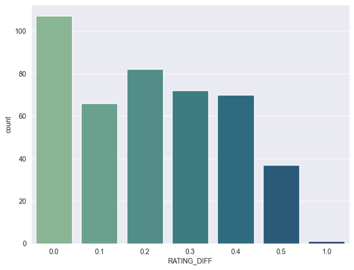

```python
fig = plt.figure()
axes = fig.add_axes([0,0.2,1,1])
sns.countplot(data=Reviewed_films, x='RATING_DIFF', palette='crest', ax=axes)
```

```python
Reviewed_films.iloc[Reviewed_films['RATING_DIFF'].argmax()]
```

```
FILM           Turbo Kid (2015)
STARS                       5.0
RATING                      4.0
VOTES                         2
YEAR                       2015
RATING_DIFF                 1.0
Name: 381, dtype: object
```

## Part Three: Comparison of Fandango Ratings to Other Sites

Let's now compare the scores from Fandango to other movies sites and see how they compare.

```python
all_sites = pd.read_csv("all_sites_scores.csv")
all_sites.head()
```

|  | FILM | RottenTomatoes | RottenTomatoes_User | Metacritic | Metacritic_User | IMDB | Metacritic_user_vote_count | IMDB_user_vote_count |
| --- | --- | --- | --- | --- | --- | --- | --- | --- |
| 0 | Avengers: Age of Ultron (2015) | 74 | 86 | 66 | 7.1 | 7.8 | 1330 | 271107 |
| 1 | Cinderella (2015) | 85 | 80 | 67 | 7.5 | 7.1 | 249 | 65709 |
| 2 | Ant-Man (2015) | 80 | 90 | 64 | 8.1 | 7.8 | 627 | 103660 |
| 3 | Do You Believe? (2015) | 18 | 84 | 22 | 4.7 | 5.4 | 31 | 3136 |
| 4 | Hot Tub Time Machine 2 (2015) | 14 | 28 | 29 | 3.4 | 5.1 | 88 | 19560 |

```python
all_sites.info()
```

```
<class 'pandas.core.frame.DataFrame'>
RangeIndex: 146 entries, 0 to 145
Data columns (total 8 columns):
 #   Column                      Non-Null Count  Dtype
---  ------                      --------------  -----
 0   FILM                        146 non-null    object
 1   RottenTomatoes              146 non-null    int64
 2   RottenTomatoes_User         146 non-null    int64
 3   Metacritic                  146 non-null    int64
 4   Metacritic_User             146 non-null    float64
 5   IMDB                        146 non-null    float64
 6   Metacritic_user_vote_count  146 non-null    int64
 7   IMDB_user_vote_count        146 non-null    int64
dtypes: float64(2), int64(5), object(1)
memory usage: 9.3+ KB
```

```python
all_sites.describe()
```

|  | RottenTomatoes | RottenTomatoes_User | Metacritic | Metacritic_User | IMDB | Metacritic_user_vote_count | IMDB_user_vote_count |
| --- | --- | --- | --- | --- | --- | --- | --- |
| count | 146.000000 | 146.000000 | 146.000000 | 146.000000 | 146.000000 | 146.000000 | 146.000000 |
| mean | 60.849315 | 63.876712 | 58.808219 | 6.519178 | 6.736986 | 185.705479 | 42846.205479 |
| std | 30.168799 | 20.024430 | 19.517389 | 1.510712 | 0.958736 | 316.606515 | 67406.509171 |
| min | 5.000000 | 20.000000 | 13.000000 | 2.400000 | 4.000000 | 4.000000 | 243.000000 |
| 25% | 31.250000 | 50.000000 | 43.500000 | 5.700000 | 6.300000 | 33.250000 | 5627.000000 |
| 50% | 63.500000 | 66.500000 | 59.000000 | 6.850000 | 6.900000 | 72.500000 | 19103.000000 |
| 75% | 89.000000 | 81.000000 | 75.000000 | 7.500000 | 7.400000 | 168.500000 | 45185.750000 |
| max | 100.000000 | 94.000000 | 94.000000 | 9.600000 | 8.600000 | 2375.000000 | 334164.000000 |

### Rotten Tomatoes

Let's first take a look at Rotten Tomatoes. RT has two sets of reviews, their critics reviews (ratings published by official critics) and user reviews.

Scatterplot exploring the relationship between RT Critic reviews and RT User reviews.

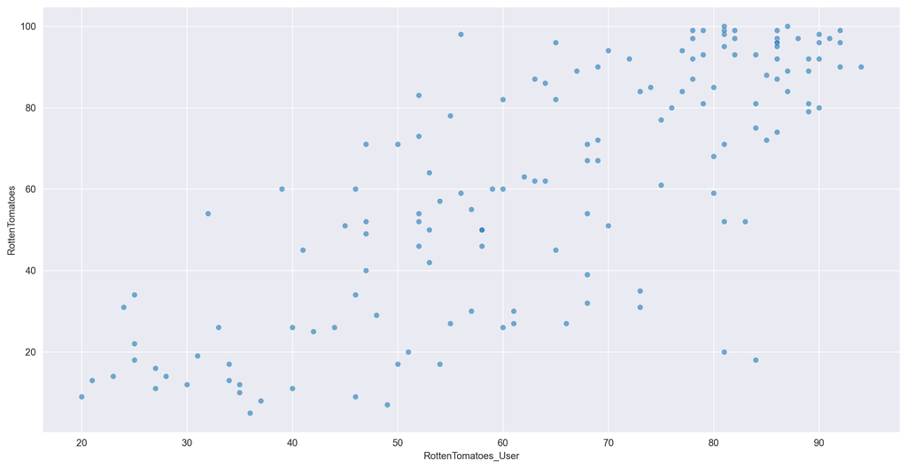

```python
plt.figure(figsize=(16,8), dpi=250)
sns.scatterplot(data=all_sites, x='RottenTomatoes_User', y='RottenTomatoes', alpha=0.6)
```

Quantifying the difference between critics and users ratings from Rotten Tomatoes [RT-RTU]

```python
all_sites['Rotten_diff'] = all_sites['RottenTomatoes'] - all_sites['RottenTomatoes_User']
all_sites['Rotten_diff']
```

```
0     -12
1       5
2     -10
3     -66
4     -14
       ..
141     9
142    15
143    19
144    19
145    24
Name: Rotten_diff, Length: 146, dtype: int64
```

Comparing the overall absolute mean difference.

```python
all_sites['Rotten_diff'].abs().mean()
```

```
15.095890410958905
```

Plotting the distribution of the differences between RT Critics Score and RT User Score.

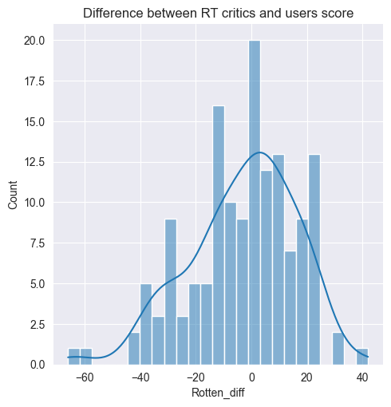

```python
sns.displot(data=all_sites, x='Rotten_diff', kde=True, bins=25).set(title='Difference between RT critics and users score')
```

Same distribution plot showing the *absolute value* difference between Critics and Users on Rotten Tomatoes.

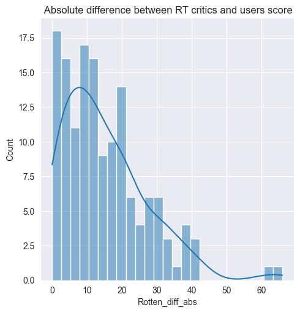

```python
all_sites['Rotten_diff_abs'] = all_sites['Rotten_diff'].abs()
sns.displot(data=all_sites, x='Rotten_diff_abs', kde=True, bins=25).set(title=' Absolute difference between RT critics and users score')
```

Top 5 movies users rated higher than critics on average

```python
all_sites.nsmallest(5, 'Rotten_diff')[['FILM', 'Rotten_diff']]
```

|  | FILM | Rotten_diff |
| --- | --- | --- |
| 3 | Do You Believe? (2015) | -66 |
| 85 | Little Boy (2015) | -61 |
| 105 | Hitman: Agent 47 (2015) | -42 |
| 134 | The Longest Ride (2015) | -42 |
| 125 | The Wedding Ringer (2015) | -39 |

Top 5 movies critics scores higher than users on average

```python
all_sites.nlargest(5, 'Rotten_diff')[['FILM', 'Rotten_diff']]
```

|  | FILM | Rotten_diff |
| --- | --- | --- |
| 69 | Mr. Turner (2014) | 42 |
| 112 | It Follows (2015) | 31 |
| 115 | While We're Young (2015) | 31 |
| 37 | Welcome to Me (2015) | 24 |
| 40 | I'll See You In My Dreams (2015) | 24 |

## MetaCritic

Now let's take a quick look at the ratings from MetaCritic. Metacritic also shows an average user rating versus their official displayed rating.

Scatterplot of the Metacritic Rating versus the Metacritic User rating.

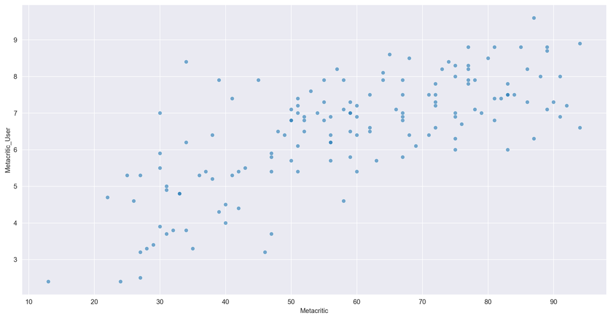

```python
plt.figure(figsize=(16,8), dpi=250)
sns.scatterplot(data=all_sites, x='Metacritic', y= 'Metacritic_User', alpha=0.6)
```

## IMDB

Finally let's explore IMDB. Both Metacritic and IMDB report back vote counts. Let's analyze the most popular movies.

Scatterplot for the relationship between vote counts on MetaCritic versus vote counts on IMDB.

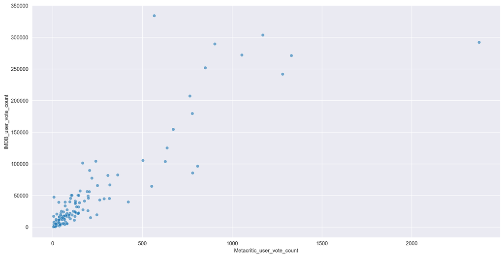

```python
plt.figure(figsize=(16,8), dpi=250)
sns.scatterplot(data=all_sites, x='Metacritic_user_vote_count', y= 'IMDB_user_vote_count', alpha=0.6)
```

```python
all_sites.nlargest(1, 'IMDB_user_vote_count')
```

|  | FILM | RottenTomatoes | RottenTomatoes_User | Metacritic | Metacritic_User | IMDB | Metacritic_user_vote_count | IMDB_user_vote_count | Rotten_diff | Rotten_diff_abs |
| --- | --- | --- | --- | --- | --- | --- | --- | --- | --- | --- |
| 14 | The Imitation Game (2014) | 90 | 92 | 73 | 8.2 | 8.1 | 566 | 334164 | -2 | 2 |

Movie with the highest Metacritic User Vote count

```python
all_sites.nlargest(1, 'Metacritic_user_vote_count')
```

|  | FILM | RottenTomatoes | RottenTomatoes_User | Metacritic | Metacritic_User | IMDB | Metacritic_user_vote_count | IMDB_user_vote_count | Rotten_diff | Rotten_diff_abs |
| --- | --- | --- | --- | --- | --- | --- | --- | --- | --- | --- |
| 88 | Mad Max: Fury Road (2015) | 97 | 88 | 89 | 8.7 | 8.3 | 2375 | 292023 | 9 | 9 |

## Fandago Scores vs. All Sites

Finally let's begin to explore whether or not Fandango artificially displays higher ratings than warranted to boost ticket sales.

Combining the Fandango Table with the All Sites table.

```python
Combined_sites = fandango.merge(all_sites, how='inner', on='FILM')
Combined_sites.info()
```

```
<class 'pandas.core.frame.DataFrame'>
RangeIndex: 145 entries, 0 to 144
Data columns (total 14 columns):
 #   Column                      Non-Null Count  Dtype
---  ------                      --------------  -----
 0   FILM                        145 non-null    object
 1   STARS                       145 non-null    float64
 2   RATING                      145 non-null    float64
 3   VOTES                       145 non-null    int64
 4   YEAR                        145 non-null    object
 5   RottenTomatoes              145 non-null    int64
 6   RottenTomatoes_User         145 non-null    int64
 7   Metacritic                  145 non-null    int64
 8   Metacritic_User             145 non-null    float64
 9   IMDB                        145 non-null    float64
 10  Metacritic_user_vote_count  145 non-null    int64
 11  IMDB_user_vote_count        145 non-null    int64
 12  Rotten_diff                 145 non-null    int64
 13  Rotten_diff_abs             145 non-null    int64
dtypes: float64(4), int64(8), object(2)
memory usage: 16.0+ KB
```

```python
Combined_sites.head()
```

|  | FILM | STARS | RATING | VOTES | YEAR | RottenTomatoes | RottenTomatoes_User | Metacritic | Metacritic_User | IMDB | Metacritic_user_vote_count | IMDB_user_vote_count | Rotten_diff | Rotten_diff_abs |
| --- | --- | --- | --- | --- | --- | --- | --- | --- | --- | --- | --- | --- | --- | --- |
| 0 | Fifty Shades of Grey (2015) | 4.0 | 3.9 | 34846 | 2015 | 25 | 42 | 46 | 3.2 | 4.2 | 778 | 179506 | -17 | 17 |
| 1 | Jurassic World (2015) | 4.5 | 4.5 | 34390 | 2015 | 71 | 81 | 59 | 7.0 | 7.3 | 1281 | 241807 | -10 | 10 |
| 2 | American Sniper (2015) | 5.0 | 4.8 | 34085 | 2015 | 72 | 85 | 72 | 6.6 | 7.4 | 850 | 251856 | -13 | 13 |
| 3 | Furious 7 (2015) | 5.0 | 4.8 | 33538 | 2015 | 81 | 84 | 67 | 6.8 | 7.4 | 764 | 207211 | -3 | 3 |
| 4 | Inside Out (2015) | 4.5 | 4.5 | 15749 | 2015 | 98 | 90 | 94 | 8.9 | 8.6 | 807 | 96252 | 8 | 8 |

### Normalizing columns to Fandango STARS and RATINGS 0-5

Notice that RT,Metacritic, and IMDB don't use a score between 0-5 stars like Fandango does. In order to do a fair comparison, we need to *normalize* these values so they all fall between 0-5 stars and the relationship between reviews stays the same.

```python
Combined_sites['RT_Norm'] = np.round(Combined_sites['RottenTomatoes']/20,1)
Combined_sites['RTU_Norm'] =  np.round(Combined_sites['RottenTomatoes_User']/20,1)

Combined_sites['Meta_Norm'] =  np.round(Combined_sites['Metacritic']/20,1)
Combined_sites['Meta_U_Norm'] =  np.round(Combined_sites['Metacritic_User']/2,1)

Combined_sites['IMDB_Norm'] = np.round(Combined_sites['IMDB']/2,1)

Combined_sites.head()
```

|  | FILM | STARS | RATING | VOTES | YEAR | RottenTomatoes | RottenTomatoes_User | Metacritic | Metacritic_User | IMDB | Metacritic_user_vote_count | IMDB_user_vote_count | Rotten_diff | Rotten_diff_abs | RT_Norm | RTU_Norm | Meta_Norm | Meta_U_Norm | IMDB_Norm |
| --- | --- | --- | --- | --- | --- | --- | --- | --- | --- | --- | --- | --- | --- | --- | --- | --- | --- | --- | --- |
| 0 | Fifty Shades of Grey (2015) | 4.0 | 3.9 | 34846 | 2015 | 25 | 42 | 46 | 3.2 | 4.2 | 778 | 179506 | -17 | 17 | 1.2 | 2.1 | 2.3 | 1.6 | 2.1 |
| 1 | Jurassic World (2015) | 4.5 | 4.5 | 34390 | 2015 | 71 | 81 | 59 | 7.0 | 7.3 | 1281 | 241807 | -10 | 10 | 3.6 | 4.0 | 3.0 | 3.5 | 3.6 |
| 2 | American Sniper (2015) | 5.0 | 4.8 | 34085 | 2015 | 72 | 85 | 72 | 6.6 | 7.4 | 850 | 251856 | -13 | 13 | 3.6 | 4.2 | 3.6 | 3.3 | 3.7 |
| 3 | Furious 7 (2015) | 5.0 | 4.8 | 33538 | 2015 | 81 | 84 | 67 | 6.8 | 7.4 | 764 | 207211 | -3 | 3 | 4.0 | 4.2 | 3.4 | 3.4 | 3.7 |
| 4 | Inside Out (2015) | 4.5 | 4.5 | 15749 | 2015 | 98 | 90 | 94 | 8.9 | 8.6 | 807 | 96252 | 8 | 8 | 4.9 | 4.5 | 4.7 | 4.4 | 4.3 |

DataFrame that only contains the normalizes ratings. Including both STARS and RATING from the original Fandango table

```python
colnamesnorm = [s for s in Combined_sites.keys() if 'Norm' in s or 'STARS' in s or 'RATING' in s]
norm_scores = Combined_sites[colnamesnorm]
norm_scores.head()
```

|  | STARS | RATING | RT_Norm | RTU_Norm | Meta_Norm | Meta_U_Norm | IMDB_Norm |
| --- | --- | --- | --- | --- | --- | --- | --- |
| 0 | 4.0 | 3.9 | 1.2 | 2.1 | 2.3 | 1.6 | 2.1 |
| 1 | 4.5 | 4.5 | 3.6 | 4.0 | 3.0 | 3.5 | 3.6 |
| 2 | 5.0 | 4.8 | 3.6 | 4.2 | 3.6 | 3.3 | 3.7 |
| 3 | 5.0 | 4.8 | 4.0 | 4.2 | 3.4 | 3.4 | 3.7 |
| 4 | 4.5 | 4.5 | 4.9 | 4.5 | 4.7 | 4.4 | 4.3 |

### Comparing Distribution of Scores Across Sites

KDE-plot comparing the distributions of normailized ratings across all sites.

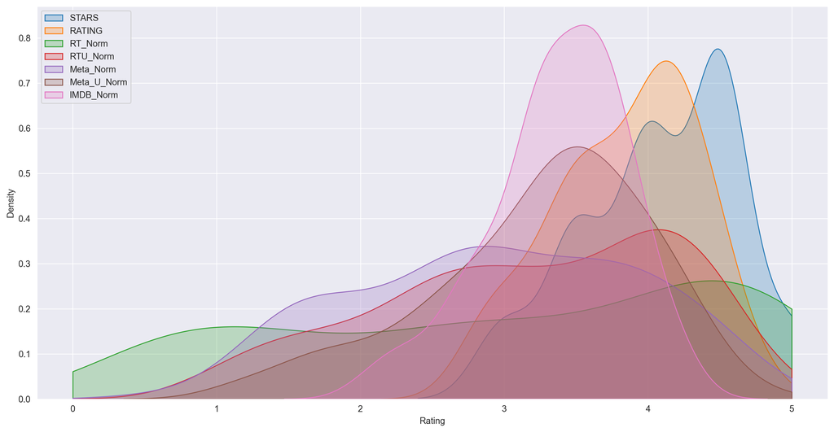

```python
plt.figure(figsize=(16,8), dpi=250)
for col in colnamesnorm:
    sns.kdeplot(data=norm_scores, x=col, label=col, fill=True, clip=(0,5))
plt.legend(loc = 'upper left')
plt.xlabel('Rating')
```

Clearly Fandango has an uneven distribution. We can also see that RT critics have the most uniform distribution. Let's directly compare these two.

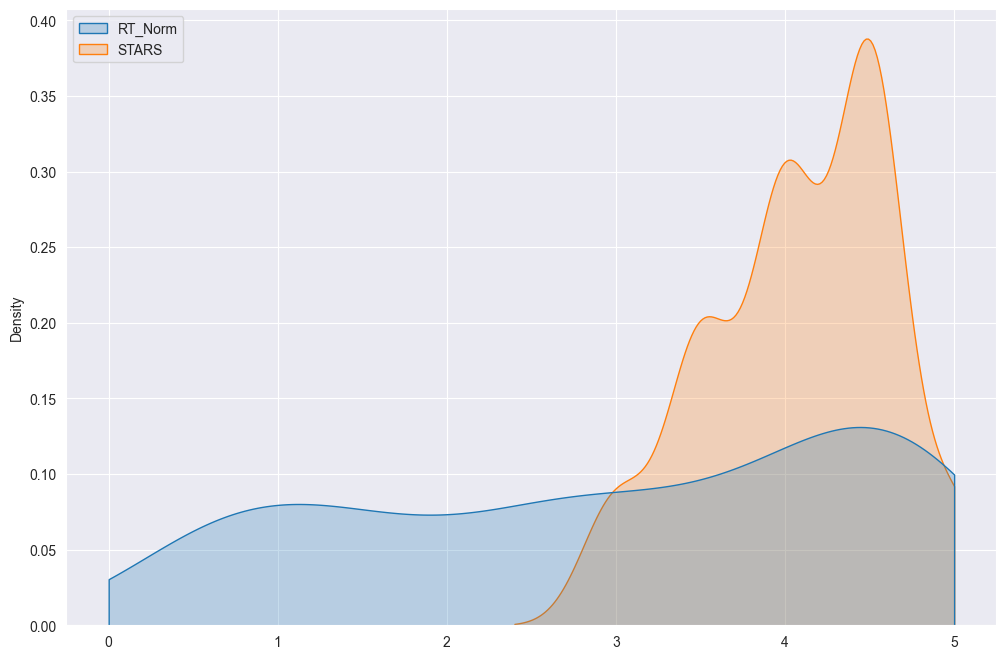

```python
plt.figure(figsize=(12,8))
ax = sns.kdeplot(data=norm_scores[['RT_Norm', 'STARS']], fill=True, clip=(0,5))
sns.move_legend(ax, 'upper left')
```

Histplot comparing all normalized scores.

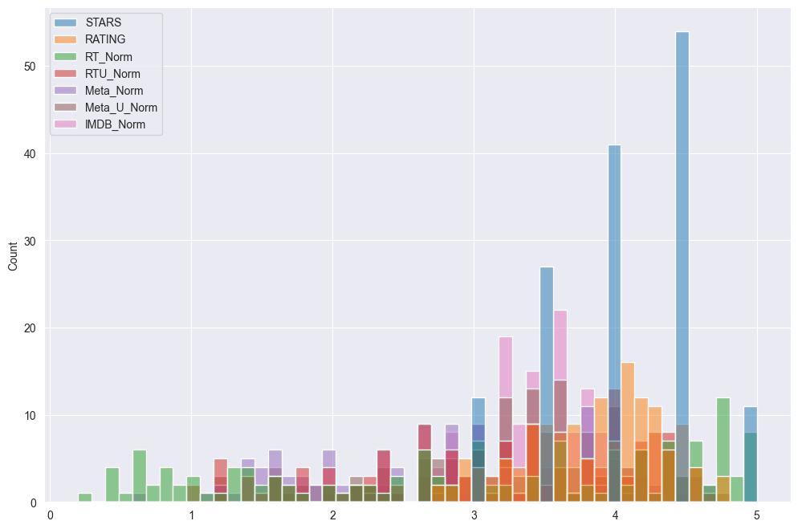

```python
plt.figure(figsize=(12,8))
sns.histplot(data=norm_scores, bins=50)
```

### How are the worst movies rated across all platforms?

Clustermap visualization of all normalized scores.

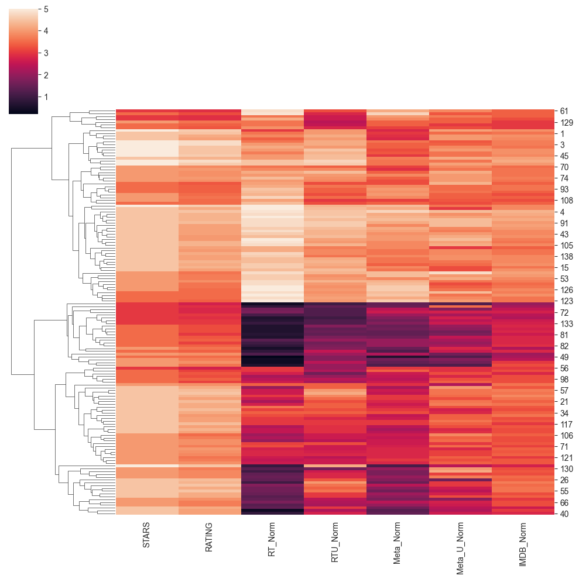

```python
sns.clustermap(data=norm_scores, col_cluster=False)
```

```python
colnamesnorm.append('FILM')

Combined_sites.nlargest(10, 'RottenTomatoes')[colnamesnorm]
```

|  | STARS | RATING | RT_Norm | RTU_Norm | Meta_Norm | Meta_U_Norm | IMDB_Norm | FILM |
| --- | --- | --- | --- | --- | --- | --- | --- | --- |
| 128 | 3.5 | 3.5 | 5.0 | 4.0 | 4.5 | 3.6 | 3.9 | Gett: The Trial of Viviane Amsalem (2015) |
| 139 | 4.5 | 4.2 | 5.0 | 4.4 | 4.2 | 3.0 | 3.8 | Seymour: An Introduction (2015) |
| 23 | 5.0 | 4.6 | 5.0 | 4.3 | 4.4 | 3.6 | 3.8 | Selma (2014) |
| 85 | 4.5 | 4.0 | 5.0 | 4.1 | 4.0 | 4.4 | 3.7 | Shaun the Sheep Movie (2015) |
| 122 | 4.0 | 3.6 | 5.0 | 3.9 | 4.6 | 3.4 | 3.6 | Timbuktu (2015) |
| 123 | 3.5 | 3.4 | 5.0 | 4.0 | 4.6 | 4.0 | 3.6 | Phoenix (2015) |
| 124 | 4.5 | 4.3 | 5.0 | 4.6 | 4.3 | 4.1 | 4.1 | Song of the Sea (2014) |
| 126 | 4.0 | 3.5 | 5.0 | 4.0 | 4.6 | 3.6 | 3.8 | Leviathan (2014) |
| 4 | 4.5 | 4.5 | 4.9 | 4.5 | 4.7 | 4.4 | 4.3 | Inside Out (2015) |
| 39 | 4.5 | 4.3 | 4.9 | 4.0 | 3.8 | 4.1 | 3.6 | Paddington (2015) |

Visualizing the distribution of ratings across all sites for the top 10 worst movies.

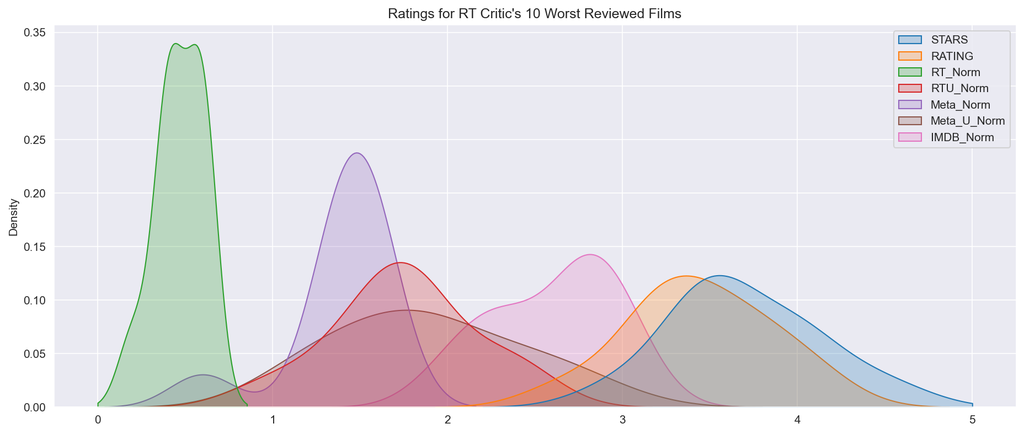

```python
plt.figure(figsize=(15,6),dpi=150)
worst_films = norm_scores.nsmallest(10, 'RT_Norm')
sns.kdeplot(data=worst_films,clip=[0,5],fill=True).set(title = "Ratings for RT Critic's 10 Worst Reviewed Films");
```